# R Studio Exercise 3

### Q2. Reading and exploring the data

```r
setwd("C:/Users/Teppo/Documents/GitHub/IODS-project/data")

alc <- read.csv("alc.csv", row.names = 1)
colnames(alc)
```

```
##  [1] "school"     "sex"        "age"        "address"    "famsize"
##  [6] "Pstatus"    "Medu"       "Fedu"       "Mjob"       "Fjob"
## [11] "reason"     "nursery"    "internet"   "guardian"   "traveltime"
## [16] "studytime"  "failures"   "schoolsup"  "famsup"     "paid"
## [21] "activities" "higher"     "romantic"   "famrel"     "freetime"
## [26] "goout"      "Dalc"       "Walc"       "health"     "absences"
## [31] "G1"         "G2"         "G3"         "alc_use"    "high_use"
```

```r
str(alc)
```

```
## 'data.frame':    382 obs. of  35 variables:
##  $ school    : Factor w/ 2 levels "GP","MS": 1 1 1 1 1 1 1 1 1 1 ...
##  $ sex       : Factor w/ 2 levels "F","M": 1 1 1 1 1 2 2 1 2 2 ...
##  $ age       : int  18 17 15 15 16 16 16 17 15 15 ...
##  $ address   : Factor w/ 2 levels "R","U": 2 2 2 2 2 2 2 2 2 2 ...
##  $ famsize   : Factor w/ 2 levels "GT3","LE3": 1 1 2 1 1 2 2 1 2 1 ...
##  $ Pstatus   : Factor w/ 2 levels "A","T": 1 2 2 2 2 2 2 1 1 2 ...
##  $ Medu      : int  4 1 1 4 3 4 2 4 3 3 ...
##  $ Fedu      : int  4 1 1 2 3 3 2 4 2 4 ...
##  $ Mjob      : Factor w/ 5 levels "at_home","health",..: 1 1 1 2 3 4 3 3 4 3 ...
##  $ Fjob      : Factor w/ 5 levels "at_home","health",..: 5 3 3 4 3 3 3 5 3 3 ...
##  $ reason    : Factor w/ 4 levels "course","home",..: 1 1 3 2 2 4 2 2 2 2 ...
##  $ nursery   : Factor w/ 2 levels "no","yes": 2 1 2 2 2 2 2 2 2 2 ...
##  $ internet  : Factor w/ 2 levels "no","yes": 1 2 2 2 1 2 2 1 2 2 ...
##  $ guardian  : Factor w/ 3 levels "father","mother",..: 2 1 2 2 1 2 2 2 2 2 ...
```

[output cut: 21 more lines]

The dataset I am working with consist of 35 different features regarding demographics, studies and social life of 382 Portuguese students. Speficially, it includes data on grades and alcohol consumption.

### Q3. Picking explanatory variables

My analysis pursues to study whether a relatively high level of alcohol consumption among students could be predicted based on social treats. To do this, I have picked four variables for closer examination. The variables are the following:

**Medu** - mother’s education, ranging from “none” to “higher education”

**studytime** - weekly study time, ranging from less than 2 hours to over 10 hours

**activities** - extra-curricular activities, with binary response.

**Pstatus** - parent’s cohabitation status, with binary response

In short, I hypothesise that mother’s education, study time and extra-curricular activities are negatively associated with high levels of alcohol consumption. For parent’s cohabitation status, I predict that with no cohabitation the risk of high alcohol consumption is greater.

### Q4. Numerical and graphical exploration

Preparation:

```r
# Preparing variables for analysis
alc$activities <- as.numeric(alc$activities)
alc$Pstatus <- as.numeric(alc$Pstatus)

# Installing relevant packages
library(dplyr)
library(ggplot2)
```

Correlation coefficients, distributional plots and cross tabulations.

```r
# Simple correlation coefficients
cor(alc$high_use, alc$Medu)
```

```
## [1] 0.01098796
```

```r
cor(alc$high_use, alc$studytime)
```

```
## [1] -0.2063247
```

```r
cor(alc$high_use, alc$activities)
```

```
## [1] -0.05710969
```

```r
cor(alc$high_use, alc$Pstatus)
```

```
## [1] -0.01260984
```

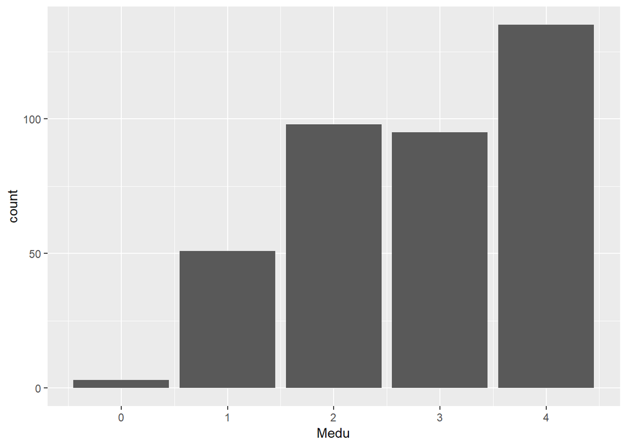

```r
# Distributional plots
g1 <- ggplot(alc, aes(x = Medu))
g2 <- ggplot(alc, aes(x = studytime))
g3 <- ggplot(alc, aes(x = activities))
g4 <- ggplot(alc, aes(x = Pstatus))

g1 + geom_bar()
```

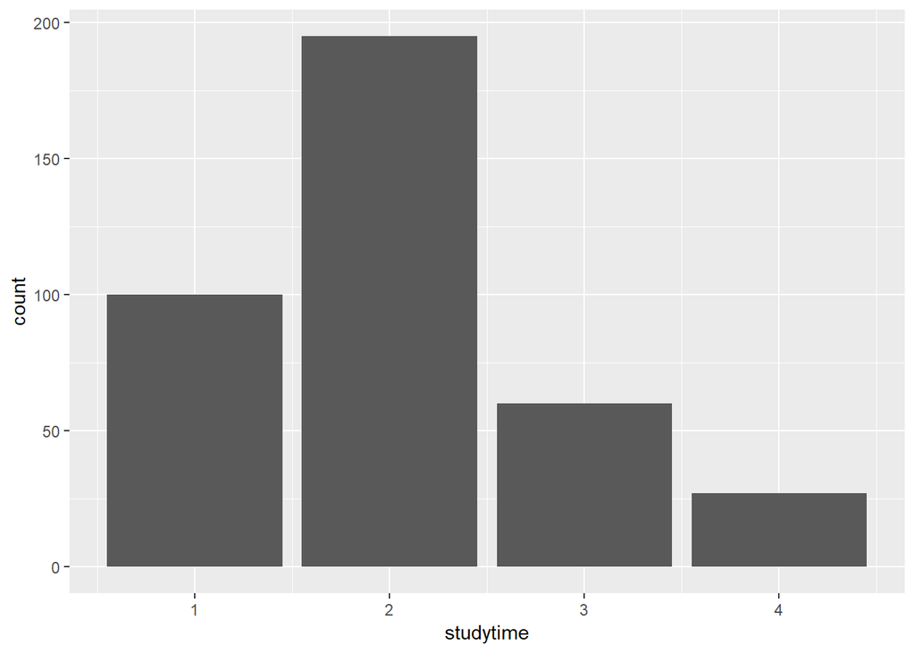

```r
g2 + geom_bar()
```

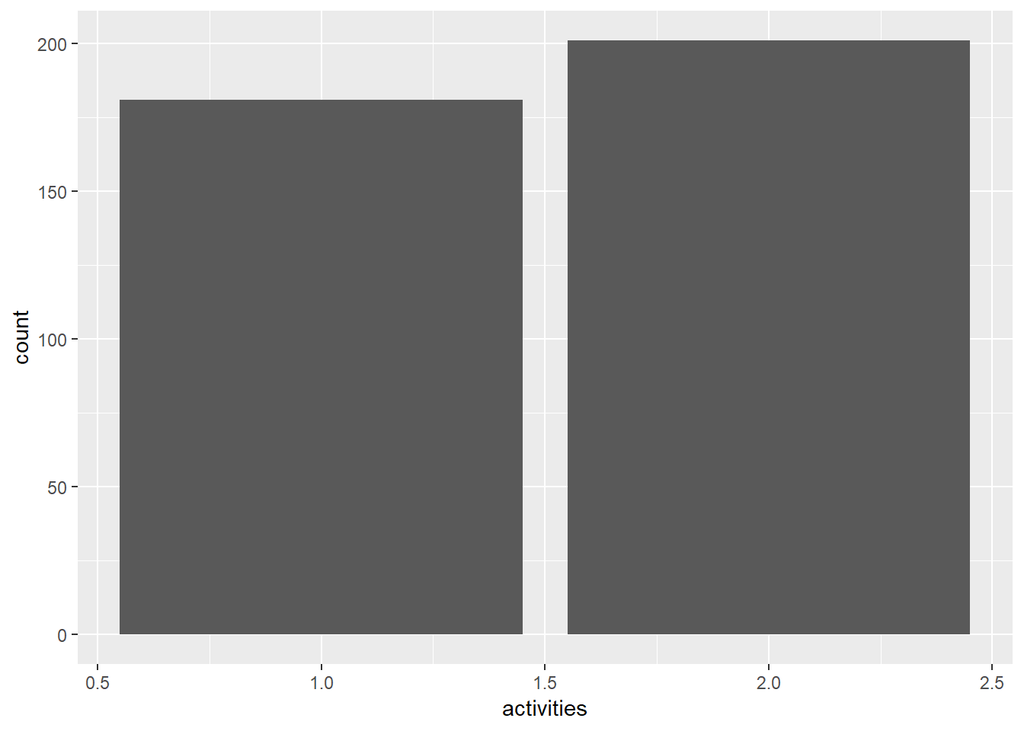

```r
g3 + geom_bar()
```

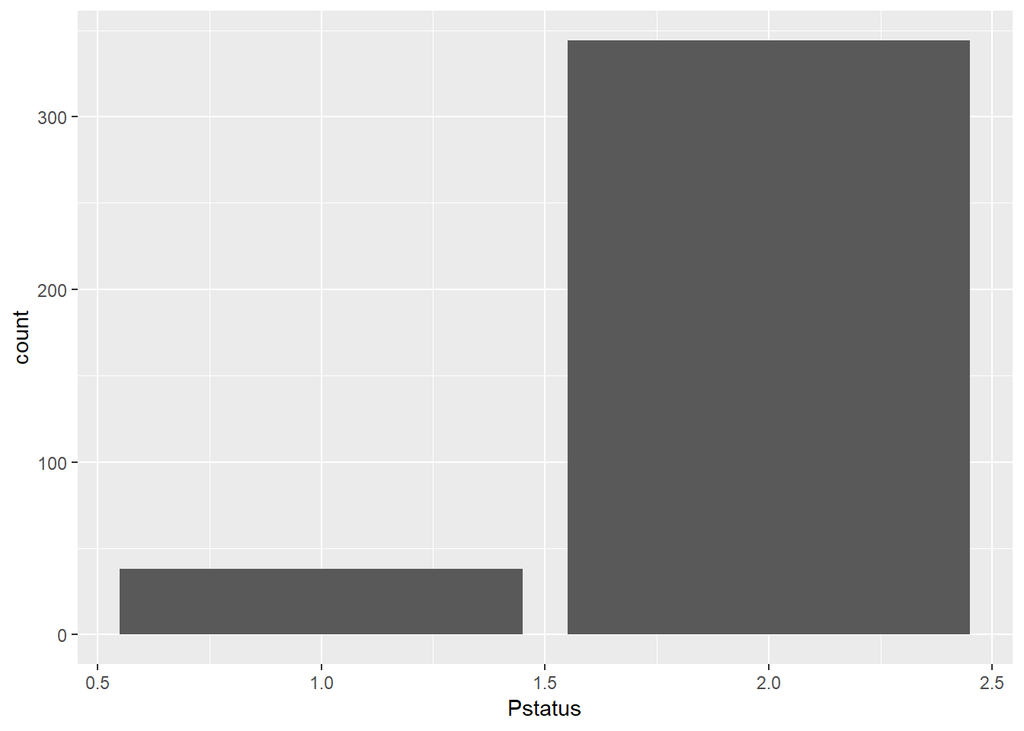

```r
g4 + geom_bar()
```

```r
# Cross tabulations
table(alc$high_use, alc$Medu)
```

```
##
##          0  1  2  3  4
##   FALSE  1 33 80 59 95
##   TRUE   2 18 18 36 40
```

```r
table(alc$high_use, alc$studytime)
```

```
##
##           1   2   3   4
##   FALSE  58 135  52  23
##   TRUE   42  60   8   4
```

```r
table(alc$high_use, alc$activities)
```

```
##
##           1   2
##   FALSE 122 146
##   TRUE   59  55
```

```r
table(alc$high_use, alc$Pstatus)
```

```
##
##           1   2
##   FALSE  26 242
##   TRUE   12 102
```

Moving on to connections between variables, the accuracy of my hypotheses is at best mixed. The most precise prediction is the one on study time, which is negatively correlated with high levels of alcohol consumption. All the other correlations are very close to zero, and the sign on mother’s education is actually *positive*.

### Q5. Logistic regression

```r
m1 <- glm(high_use ~ Medu + studytime + activities + Pstatus, data = alc, family = binomial)
summary(m1)
```

```
##
## Call:
## glm(formula = high_use ~ Medu + studytime + activities + Pstatus,
##     family = binomial, data = alc)
##
## Deviance Residuals:
##     Min       1Q   Median       3Q      Max
## -1.1253  -0.8471  -0.7652   1.2821   2.1530
##
## Coefficients:
##              Estimate Std. Error z value Pr(>|z|)
## (Intercept)  0.403199   0.884197   0.456 0.648386
## Medu         0.059429   0.107267   0.554 0.579564
## studytime   -0.597435   0.153868  -3.883 0.000103 ***
## activities  -0.178867   0.232579  -0.769 0.441860
## Pstatus      0.005724   0.380914   0.015 0.988011
## ---
## Signif. codes:  0 '***' 0.001 '**' 0.01 '*' 0.05 '.' 0.1 ' ' 1
##
## (Dispersion parameter for binomial family taken to be 1)
##
##     Null deviance: 465.68  on 381  degrees of freedom
## Residual deviance: 447.49  on 377  degrees of freedom
## AIC: 457.49
##
## Number of Fisher Scoring iterations: 4
```

```r
exp(coef(m1))
```

```
## (Intercept)        Medu   studytime  activities     Pstatus
##   1.4966050   1.0612299   0.5502210   0.8362175   1.0057402
```

```r
exp(confint(m1))
```

```
##                 2.5 %    97.5 %
## (Intercept) 0.2544469 8.3124648
## Medu        0.8608816 1.3120240
## studytime   0.4030077 0.7375984
## activities  0.5295809 1.3198457
## Pstatus     0.4856696 2.1873461
```

To ease interpretation, I exponentiated the coefficients from the logistic regression, and computed their respective confidence intervals. Now, the numbers represent odds ratios. As expected, for the three variables excluding study time the estimated confidence interval contains one. This implies, that we cannot tell whether an increase in each variable increases or decreases the odds of high alcohol consumption. Considering study time, however, the confidence interval is roughly 0.40-0.74, our best guess (i.e., the odds ratio) being 0.55. The interpretation is, that increasing study time for example from 2 to 5 hours to 5 to 10 hours squeezes the odds of high alcohol consumption by about 50%. An exact interpretation is awkward, since the study time categories are not of equal size.

### Q6. Evaluating predictive power

```r
m2 <- glm(high_use ~ studytime, data = alc, family = binomial)
summary(m2)
```

```
##
## Call:
## glm(formula = high_use ~ studytime, family = binomial, data = alc)
##
## Deviance Residuals:
##     Min       1Q   Median       3Q      Max
## -1.0603  -0.8314  -0.8314   1.2993   2.1010
##
## Coefficients:
##             Estimate Std. Error z value Pr(>|z|)
## (Intercept)   0.3209     0.3076   1.043    0.297
## studytime    -0.6029     0.1530  -3.941  8.1e-05 ***
## ---
## Signif. codes:  0 '***' 0.001 '**' 0.01 '*' 0.05 '.' 0.1 ' ' 1
##
## (Dispersion parameter for binomial family taken to be 1)
##
##     Null deviance: 465.68  on 381  degrees of freedom
## Residual deviance: 448.31  on 380  degrees of freedom
## AIC: 452.31
##
## Number of Fisher Scoring iterations: 4
```

Prediction accuracy:

```r
probabilities <- predict(m2, type = "response")
alc <- mutate(alc, probability = probabilities)
alc <- mutate(alc, prediction = probability > 0.5)
table(high_use = alc$high_use, prediction = alc$prediction) %>%
  prop.table() %>%
  addmargins()
```

```
##         prediction
## high_use     FALSE       Sum
##    FALSE 0.7015707 0.7015707
##    TRUE  0.2984293 0.2984293
##    Sum   1.0000000 1.0000000
```

```r
loss_func <- function(class, prob) {
  n_wrong <- abs(class - prob) > 0.5
  mean(n_wrong)
}
loss_func(class = alc$high_use, prob = 0)
```

```
## [1] 0.2984293
```

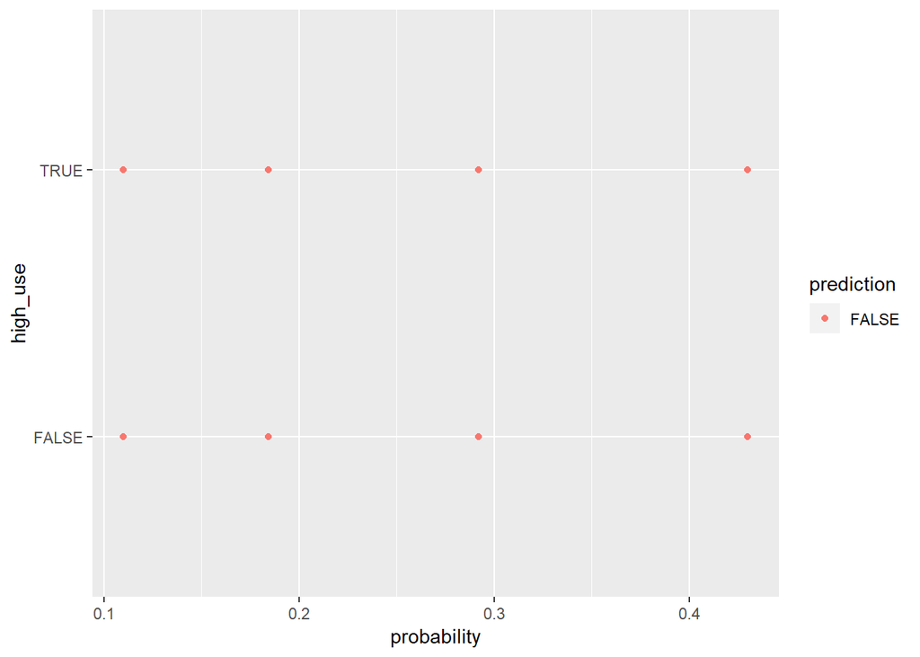

```r
alc %>%
  ggplot(aes(x = probability, y = high_use, col = prediction)) +
  geom_point()
```

Finally, I evaluate the predictive power of my logistic regression. Firstly, I do this by cross-tabulating the students who actually consume high level of alcohol, and the ones my model predicts to do so. Turns out, that after excluding the statistically insignificant variables, the bivariate model with only study times as an explanatory variable predicts that none of the students is a big drinker. Thus, the confusion matrix comes out as 2x1 matrix. Regardless, it can be concluded that the proportion of inaccurately classified individuals is roughly 30%. This result is further replicated by exploiting a loss function and drawing a rather trivial plot.

In terms of predictive power, the bivariate model is worthless compared to simply guessing that none of the students is a grand alcohol consumer: both approaches produce an identical prediction error.